# Support Vector Machine

## 1. Definition

The support vector machine algorithm finds a hyperplane in an N-dimensional space that distinctly classifies the data points.

## 2. Libraries

```python
import pandas as pd
import numpy as np

from sklearn.model_selection import train_test_split

from sklearn.svm import SVC # Support Vector Machine
from sklearn.model_selection import GridSearchCV

from sklearn.metrics import accuracy_score
from sklearn.metrics import accuracy_score

from sklearn.metrics import confusion_matrix
import seaborn as sns

from sklearn.metrics import roc_auc_score, roc_curve, plot_roc_curve
from sklearn import metrics

import matplotlib.pyplot as plt

from sklearn.metrics import classification_report

import pickle
```

## 3. Load Data

```python
loan = pd.read_csv('../data/BB.DD_MODELOS.csv')
loan.shape
```

```
(460541, 50)
```

```python
loan.head()
```

|  | Unnamed: 0 | loan_acceptance | ('acc_now_delinq',) | ('acc_open_past_24mths',) | ('all_util',) | ('annual_inc',) | ('avg_cur_bal',) | ('bc_util',) | ('collections_12_mths_ex_med',) | ('delinq_2yrs',) | ... | ('tax_liens',) | ('tot_cur_bal',) | ('total_acc',) | ('total_bal_ex_mort',) | ('total_bc_limit',) | ('total_cu_tl',) | ('total_rev_hi_lim',) | ('MORTGAGE',) | ('OWN',) | ('RENT',) |
| --- | --- | --- | --- | --- | --- | --- | --- | --- | --- | --- | --- | --- | --- | --- | --- | --- | --- | --- | --- | --- | --- |
| 0 | 0 | 1 | -0.070414 | 1.010683 | -4.391856 | 1.169092 | 0.632931 | -1.756350 | -0.121123 | -0.373769 | ... | -0.136687 | 1.966093 | 1.645054 | 1.082435 | 0.364780 | 3.872116 | 0.169542 | -0.990665 | 2.932031 | -0.817319 |
| 1 | 1 | 1 | -0.070414 | -0.889720 | 2.588767 | -0.388652 | -0.712121 | 1.344204 | -0.121123 | -0.373769 | ... | -0.136687 | -0.865215 | -1.644651 | -0.937178 | -0.813060 | -1.373566 | -0.787800 | -0.990665 | -0.341061 | 1.223512 |
| 2 | 2 | 1 | -0.070414 | 2.594353 | -3.840754 | 0.518772 | 0.083906 | -1.236562 | -0.121123 | -0.373769 | ... | -0.136687 | 0.889188 | 0.082444 | -0.081508 | 3.037755 | 3.872116 | 1.523901 | 1.009422 | -0.341061 | -0.817319 |
| 3 | 3 | 1 | -0.070414 | 0.693949 | -4.391856 | -0.358722 | -0.783204 | -1.443750 | -0.121123 | -0.373769 | ... | -0.136687 | -0.830447 | -0.411012 | -0.823391 | -0.082319 | -1.373566 | -0.081056 | -0.990665 | -0.341061 | 1.223512 |
| 4 | 4 | 1 | -0.070414 | 0.060482 | 3.690971 | -0.010558 | 1.173048 | 1.020700 | -0.121123 | 0.716465 | ... | -0.136687 | -0.074671 | -1.315681 | -0.468803 | -0.841905 | -1.373566 | -0.804695 | 1.009422 | -0.341061 | -0.817319 |

5 rows × 50 columns

```python
data = loan.iloc[:,1:]
data.head()
```

|  | loan_acceptance | ('acc_now_delinq',) | ('acc_open_past_24mths',) | ('all_util',) | ('annual_inc',) | ('avg_cur_bal',) | ('bc_util',) | ('collections_12_mths_ex_med',) | ('delinq_2yrs',) | ('delinq_amnt',) | ... | ('tax_liens',) | ('tot_cur_bal',) | ('total_acc',) | ('total_bal_ex_mort',) | ('total_bc_limit',) | ('total_cu_tl',) | ('total_rev_hi_lim',) | ('MORTGAGE',) | ('OWN',) | ('RENT',) |
| --- | --- | --- | --- | --- | --- | --- | --- | --- | --- | --- | --- | --- | --- | --- | --- | --- | --- | --- | --- | --- | --- |
| 0 | 1 | -0.070414 | 1.010683 | -4.391856 | 1.169092 | 0.632931 | -1.756350 | -0.121123 | -0.373769 | -0.018151 | ... | -0.136687 | 1.966093 | 1.645054 | 1.082435 | 0.364780 | 3.872116 | 0.169542 | -0.990665 | 2.932031 | -0.817319 |
| 1 | 1 | -0.070414 | -0.889720 | 2.588767 | -0.388652 | -0.712121 | 1.344204 | -0.121123 | -0.373769 | -0.018151 | ... | -0.136687 | -0.865215 | -1.644651 | -0.937178 | -0.813060 | -1.373566 | -0.787800 | -0.990665 | -0.341061 | 1.223512 |
| 2 | 1 | -0.070414 | 2.594353 | -3.840754 | 0.518772 | 0.083906 | -1.236562 | -0.121123 | -0.373769 | -0.018151 | ... | -0.136687 | 0.889188 | 0.082444 | -0.081508 | 3.037755 | 3.872116 | 1.523901 | 1.009422 | -0.341061 | -0.817319 |
| 3 | 1 | -0.070414 | 0.693949 | -4.391856 | -0.358722 | -0.783204 | -1.443750 | -0.121123 | -0.373769 | -0.018151 | ... | -0.136687 | -0.830447 | -0.411012 | -0.823391 | -0.082319 | -1.373566 | -0.081056 | -0.990665 | -0.341061 | 1.223512 |
| 4 | 1 | -0.070414 | 0.060482 | 3.690971 | -0.010558 | 1.173048 | 1.020700 | -0.121123 | 0.716465 | -0.018151 | ... | -0.136687 | -0.074671 | -1.315681 | -0.468803 | -0.841905 | -1.373566 | -0.804695 | 1.009422 | -0.341061 | -0.817319 |

5 rows × 49 columns

```python
X = data.drop(['loan_acceptance'], axis = 1).values
Y = data['loan_acceptance'].values
```

```python
# We use the train_test_split function from SkLearn to split our dataset in two groups, the big one is to train the
# model and the 10% (in this case) to predict.
X_train, X_test, Y_train, Y_test = train_test_split(X, Y, test_size = 0.1) # Percentage of the test group.
```

## 4. SVM Model

We use %%time to know the time that this model needs to be run with our dataset.

In the last line of the box we train the SVM with our dataset.

We had to set max_iter = 500 to be able to run the code.

```python
# This is the Support Vector Machine without hyperparameters
%%time

sv = SVC(kernel = 'linear', max_iter = 500)

sv.fit(X_train,Y_train)
```

[output not shown]

## SVM Model Hyperparameters

Now, we are going to use the GridSearchCV function to optimize the parameters that we use.

```python
param_test = {'C': [1, 6], 'kernel': ('linear', 'rbf')}
gsearch_SVM = GridSearchCV(estimator=SVC(max_iter = 200,probability=True ),
             param_grid= param_test , scoring='roc_auc', n_jobs=-2, iid=False)
```

```python
%%time
gsearch_SVM.fit(X_train, Y_train)
```

```
CPU times: user 2min 17s, sys: 1.63 s, total: 2min 18s
Wall time: 34min 2s
```

```
GridSearchCV(estimator=SVC(max_iter=200, probability=True), iid=False,
             n_jobs=-2, param_grid={'C': [1, 6], 'kernel': ('linear', 'rbf')},
             scoring='roc_auc')
```

```python
gsearch_SVM.best_params_
```

```
{'C': 6, 'kernel': 'rbf'}
```

```python
gsearch_SVM.best_estimator_
```

```
SVC(C=6, max_iter=200, probability=True)
```

```python
%%time
Best_SVM = gsearch_SVM.best_estimator_
Best_SVM.fit(X_train, Y_train)
```

```
CPU times: user 2min 16s, sys: 1.18 s, total: 2min 17s
Wall time: 2min 18s
```

```
SVC(C=6, max_iter=200, probability=True)
```

```python
# Predict
pred = Best_SVM.predict(X_test)

# We just want to print the result to check if the output is correct (0 means deny, 1 accept).
print(pred)
```

```
[0 0 1 ... 0 0 0]
```

```python
# Check its accuracy
accuracy_score(Y_test, pred)
```

```
0.41270220388665724
```

The accuracy of the base model was 0.747, so we do not get a good accuracy with the support vector machine. Actually this will be fixed using more parameters. We tried it, but, unfortunatly, our laptops need to much time to run all the models that we performed.

### Confusion Matrix

```python
loaded_model = pickle.load(open('SVM.sav', 'rb'))
result = loaded_model.score(X_test, Y_test)
pred = loaded_model.predict(X_test)
print(pred)
```

```
[0 0 0 ... 0 1 0]
```

```python
confusion_matrix = confusion_matrix(Y_test, pred )
confusion_matrix = pd.DataFrame(confusion_matrix)
```

```python
def conf_matrix(Y_test, pred):
    conf_plot = sns.heatmap(confusion_matrix, annot=True, cmap='Blues', fmt='g')
    bottom, top = conf_plot.get_ylim()
    conf_plot.set_ylim(bottom + 0.5, top - 0.5)
    conf_plot.set_ylabel('Predicted Label')
    conf_plot.set_xlabel('True Label');
```

[figure not shown]

```python
conf_matrix(Y_test, pred)
```

Looking this confusion matrix we can observe that this model is predicting quite well the right-down box, the people who paid. However, we can not say the same for the people who do not pay. If we compare the up-left box, people who do not paid detected, with the down-left box, people who do not pay but we believed that yes, our accuracy is very low.

Basically we have the same problem than with the Logistics Model.

### Confusion Matrix Normalized

```python
confusion_matrix_normalize = confusion_matrix(Y_test, pred, normalize = 'pred' )
confusion_matrix_normalize = pd.DataFrame(confusion_matrixasd)
```

```python
def conf_matrix(Y_test, pred):
    conf_plot = sns.heatmap(confusion_matrix_normalize, annot=True, cmap='Blues', fmt='g')
    bottom, top = conf_plot.get_ylim()
    conf_plot.set_ylim(bottom + 0.5, top - 0.5)
    conf_plot.set_title("Confusion matrix")
```

[figure not shown]

```python
conf_matrix(Y_test, pred)
```

### ROC Curve

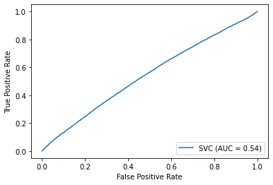

```python
metrics.plot_roc_curve(Best_SVM, X_test, Y_test)
plt.show()
```

As we can observe, our AUC using the Support Vector Machine is quite low.

### Cumulative Gain Curve

```python
predicted_probas = Best_SVM.predict_proba(X_test)
```

```python
import scikitplot as skplt
```

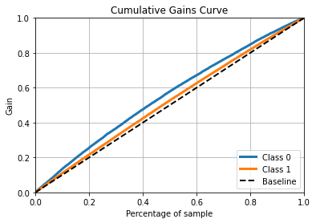

```python
skplt.metrics.plot_cumulative_gain(Y_test, predicted_probas)
plt.show()
```

### Lift Curve

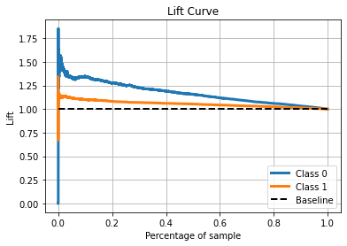

```python
skplt.metrics.plot_lift_curve(Y_test, predicted_probas)
plt.show()
```

### Histogram

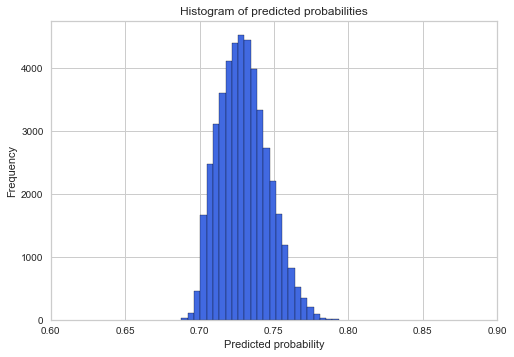

```python
y_pred_prob = predicted_probas[:, 1]

plt.rcParams['font.size'] = 12
plt.hist(y_pred_prob, bins=25,facecolor='royalblue', edgecolor = 'black')
plt.xlim(0.6,0.9)
plt.title('Histogram of predicted probabilities')
plt.xlabel('Predicted probability')
plt.ylabel('Frequency')
```

### Model Statistics

```python
print(classification_report(Y_test, pred))
```

```
              precision    recall  f1-score   support

           0       0.33      0.24      0.28     11492
           1       0.77      0.84      0.80     34563

    accuracy                           0.69     46055
   macro avg       0.55      0.54      0.54     46055
weighted avg       0.66      0.69      0.67     46055
```

We can observe again that this model has precision to detect people who pay, so it has a good score for this type of people. But, the score and precision to detect non-payers is quite bad.

### Save the model

```python
model = Best_SVM
filename = 'svm.sav'
pickle.dump(model, open(filename, 'wb'))
```